# White Wine Analysis by Bridget Nickell

# Introduction

```
##  [1] "X"                    "fixed.acidity"        "volatile.acidity"
##  [4] "citric.acid"          "residual.sugar"       "chlorides"
##  [7] "free.sulfur.dioxide"  "total.sulfur.dioxide" "density"
## [10] "pH"                   "sulphates"            "alcohol"
## [13] "quality"
```

I am also curious to see the summary of the ratings in the quality column:

```
##    Min. 1st Qu.  Median    Mean 3rd Qu.    Max.
##   3.000   5.000   6.000   5.878   6.000   9.000
```

# Univariate Plots Section

### Quality

Fist reviewing the summary of this column we see that the lowest score received was a 3 and the highest was a 9. Knowing this we can limit our code to not report on numbers 1, 2 or 10. The graph below shows a normal distribution for the Quality ratings in the data set. Most of the ratings are directly in the middle of the scores.

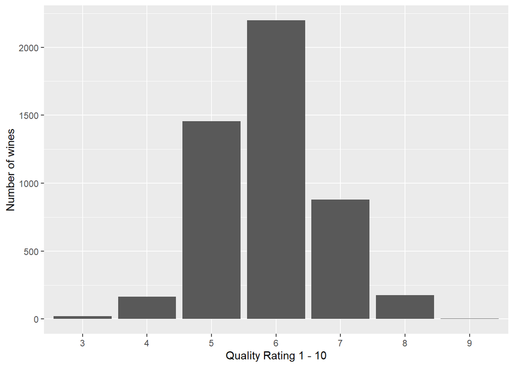

### Alcohol

First we print a summary in order to see the minimum and maximum values in the data set. The minimum value is 8 percent while the maximum value is 14.20. For the first plot there is no need to eliminate the unused percentages that are seen in the graph. From the histogram we can see that there are a a small amount of wines at the lower alcohol percentage but mostly they vary from around 8.5 to 14 percent. I have added a box plot as well to examine the alcohol percentage closer. The boxplot appears to have a right skewed distribution.

```
##    Min. 1st Qu.  Median    Mean 3rd Qu.    Max.
##    8.00    9.50   10.40   10.51   11.40   14.20
```

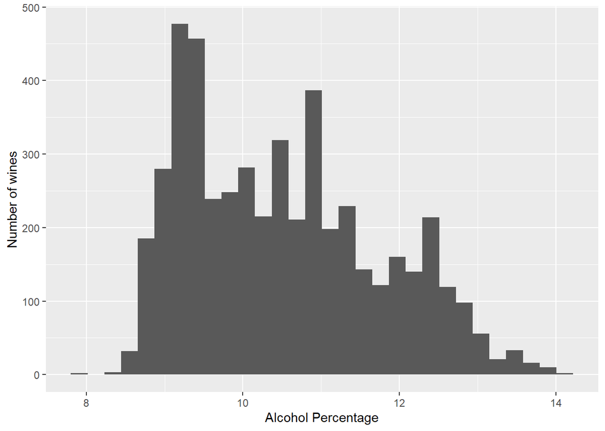

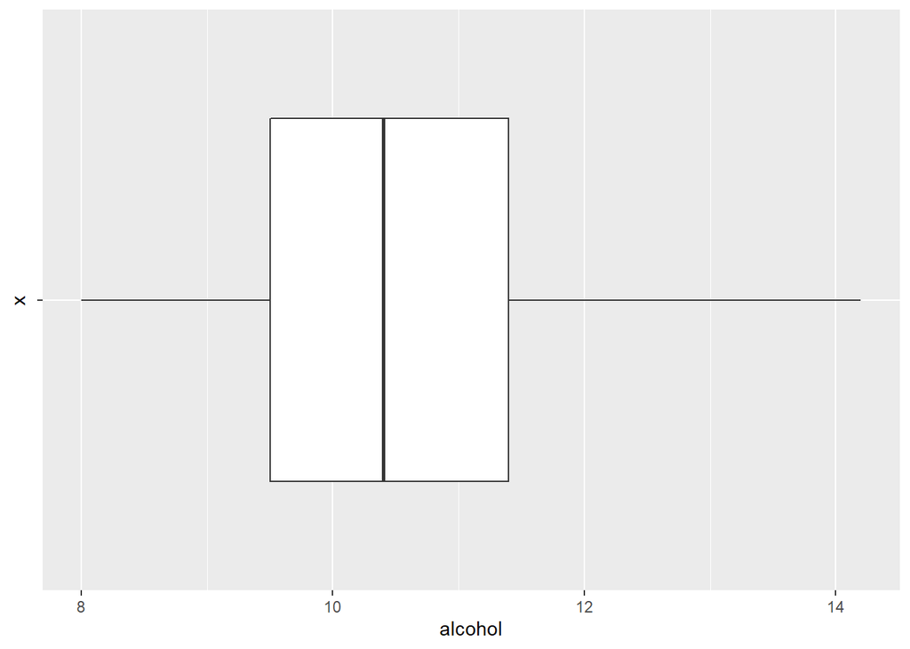

### Sulphates

Sulfates also have a right skewed distribution with somewhat of a long tail on the higher end of the proportions.

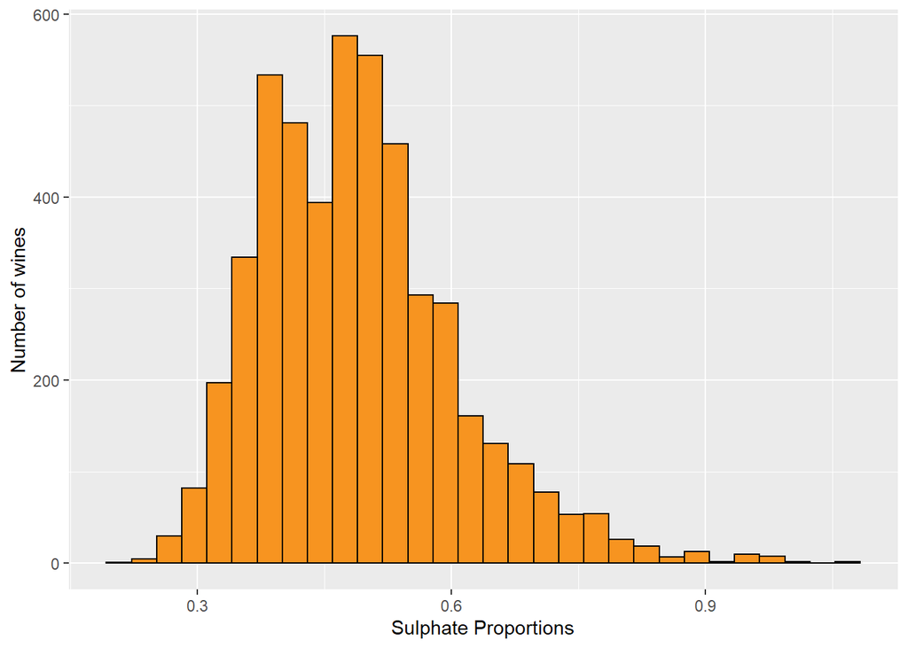

### pH

pH is normally distributed peaking at the 3.2 range of the scaling.

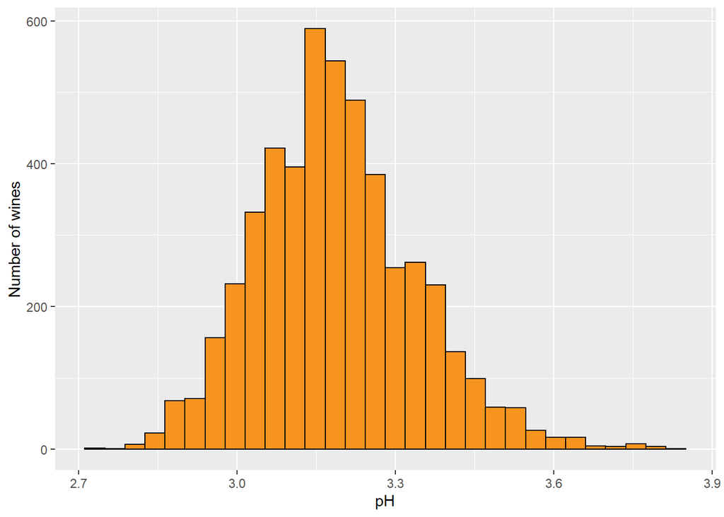

### Density

Below we see another right skewed distribution for the Density with a few outlines around 1.01 and 1.04 values.I have also shown this in a boxplot below to better show the outliers to scale.

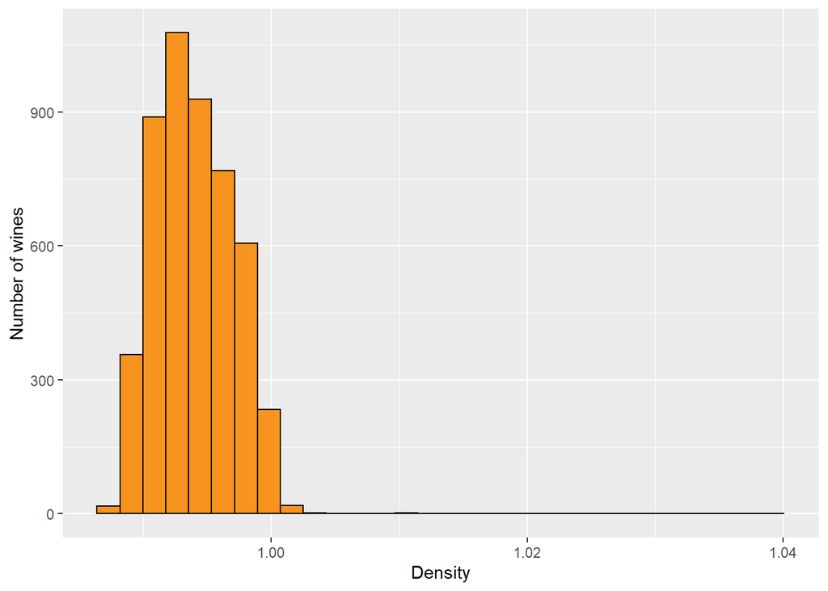

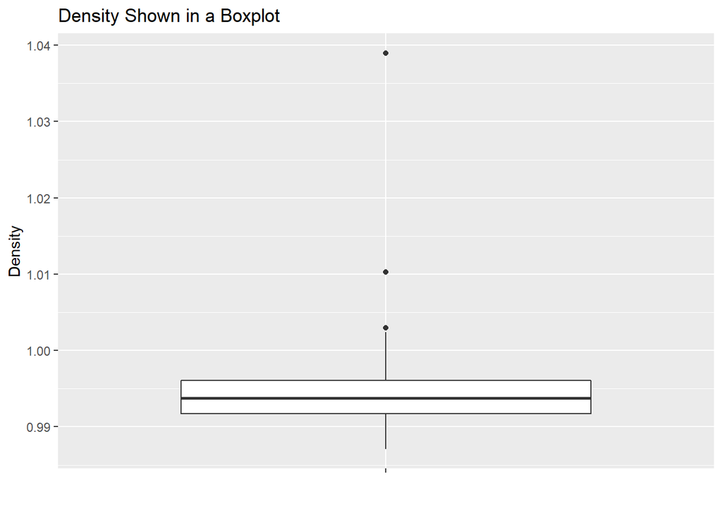

### Chlorides

Below we have another right skewed distribution shown in a histogram for the chemical component chlorides.

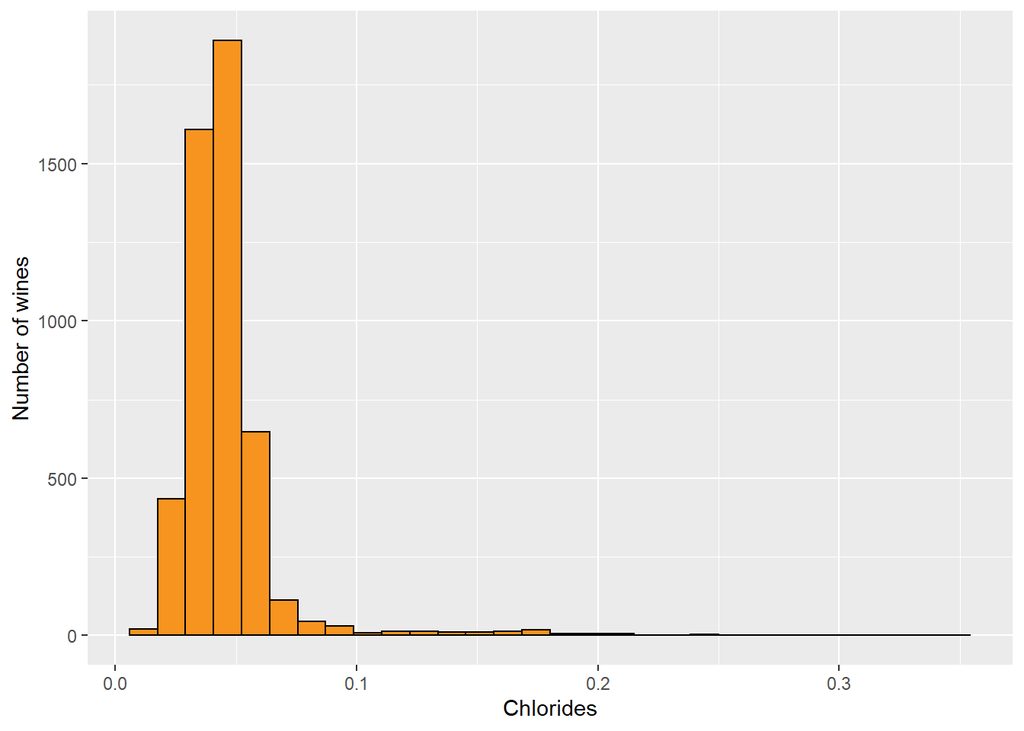

### Residual Sugar

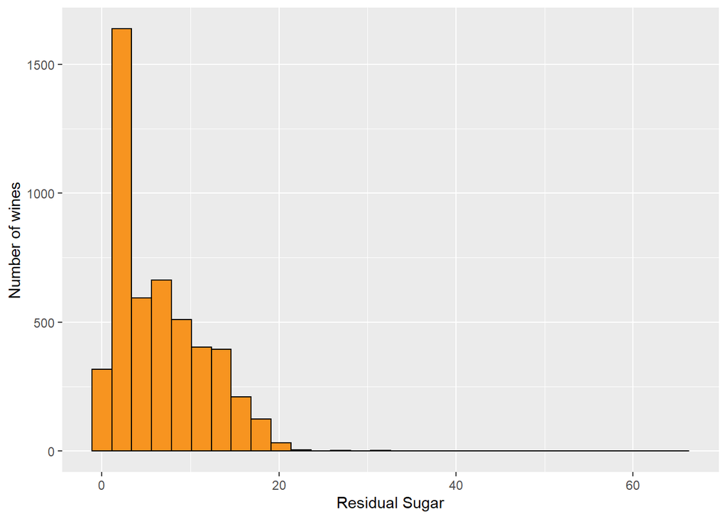

### Acids: Fixed, Volatile & Citric

Below I have three histogram visualizing the distribution of the fixed acidity, the volatile acidity and the citric acids.

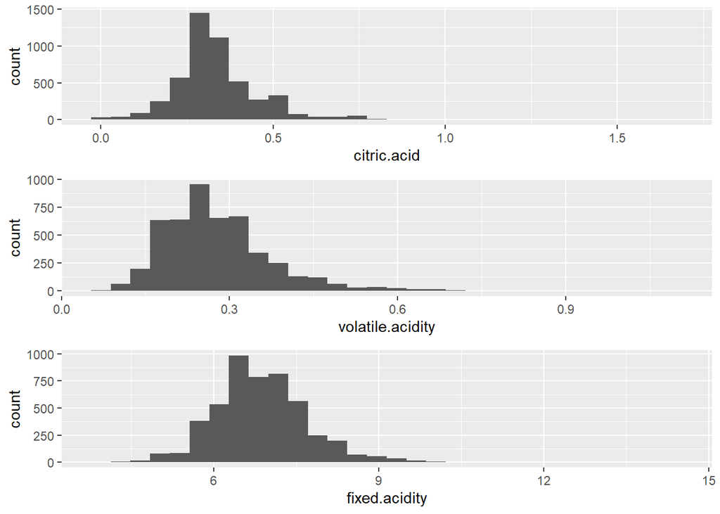

### Sulfur Dioxide(Free & total)

Below I have pictured the free and total sulfur dioxides and looking at the distribution and the numbering scale it appears that the free sulfur dioxide is about 4 times smaller in numbers when compare to the total sulfur dioxide.

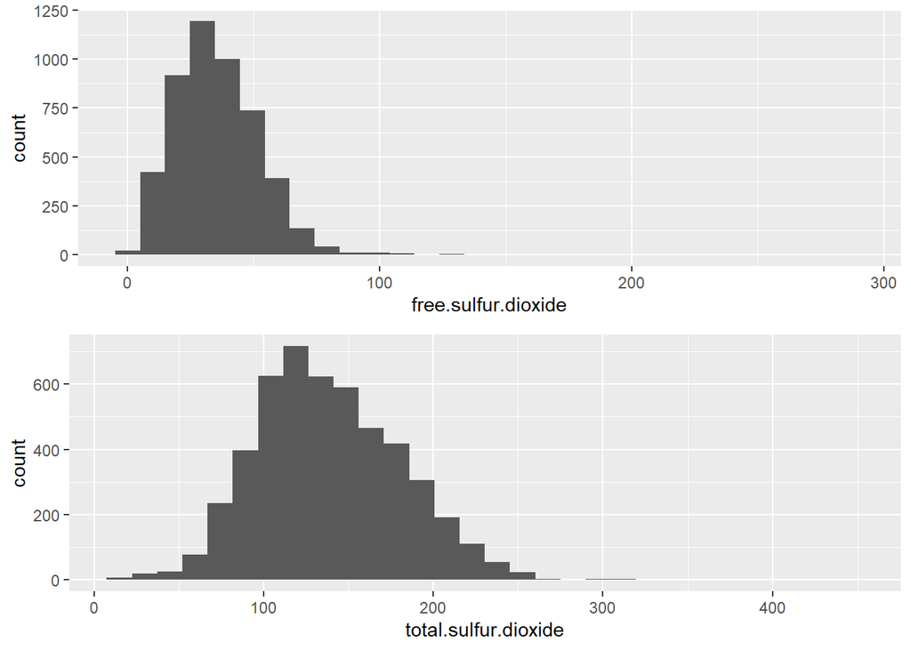

Below I wanted to get a better view of the comparison of measurements for the free and total dioxides and it seems that the majority of free sulfur dioxides are in fact about 4 times less than the amount of total sulfur dioxides.

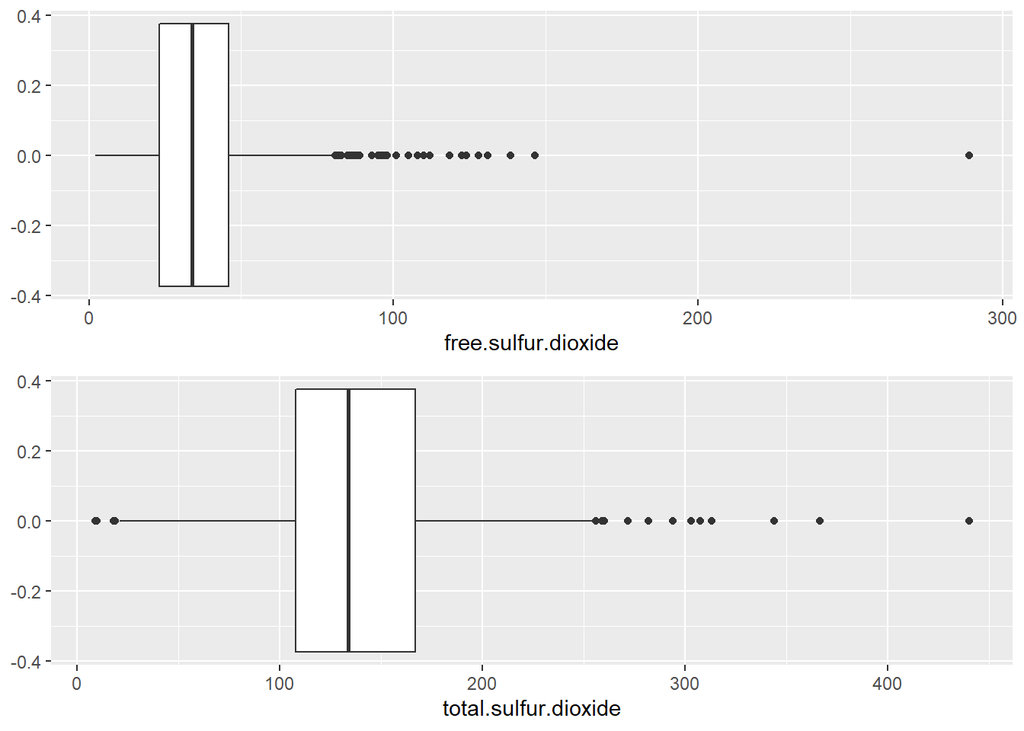

# Univariate Analysis

### What is the structure of your dataset?

```
## 'data.frame':    4898 obs. of  13 variables:
##  $ X                   : int  3266 2626 4021 3836 3840 295 460 3421 4074 1619 ...
##  $ fixed.acidity       : num  4.2 4.5 6.4 6.2 6.2 9.1 6.1 7.6 6.5 6.4 ...
##  $ volatile.acidity    : num  0.215 0.19 0.37 0.31 0.31 0.59 0.43 0.28 0.36 0.37 ...
##  $ citric.acid         : num  0.23 0.21 0.12 0.23 0.23 0.38 0.35 0.49 0.16 0.49 ...
##  $ residual.sugar      : num  5.1 0.95 5.9 3.3 3.3 ...
##  $ chlorides           : num  0.041 0.033 0.056 0.052 0.052 0.066 0.059 0.06 0.054 0.045 ...
##  $ free.sulfur.dioxide : num  64 89 6 34 34 34 83 30 11 53 ...
##  $ total.sulfur.dioxide: num  157 159 91 113 113 182 249 145 107 243 ...
##  $ density             : num  0.997 0.993 0.995 0.994 0.994 ...
##  $ pH                  : num  3.42 3.34 3.06 3.16 3.16 3.23 3.37 3.01 3.19 3.14 ...
##  $ sulphates           : num  0.44 0.42 0.46 0.48 0.48 0.38 0.5 0.44 0.39 0.48 ...
##  $ alcohol             : num  8 8 8.4 8.4 8.4 8.5 8.5 8.5 8.5 8.5 ...
##  $ quality             : int  3 5 4 5 5 3 5 5 5 6 ...
```

### What is/are the main feature(s) of interest in your dataset?

# Bivariate Plots Section

The interesting variables when looking at the Univariate plots were residual sugar, alcohol content and the free and total dioxides. Along with the dioxides I would like to see how the acidity components relate to one another as well.

### Alcohol Content Vs. Residual Sugar

Below I have chosen a scatterplot to compare the sugar and the alcohol content. I have observed that most of the Residual sugar measurements for each wine are below 20 grams. I also notice a trend that as the alcohol increase the sugar starts the decrease.

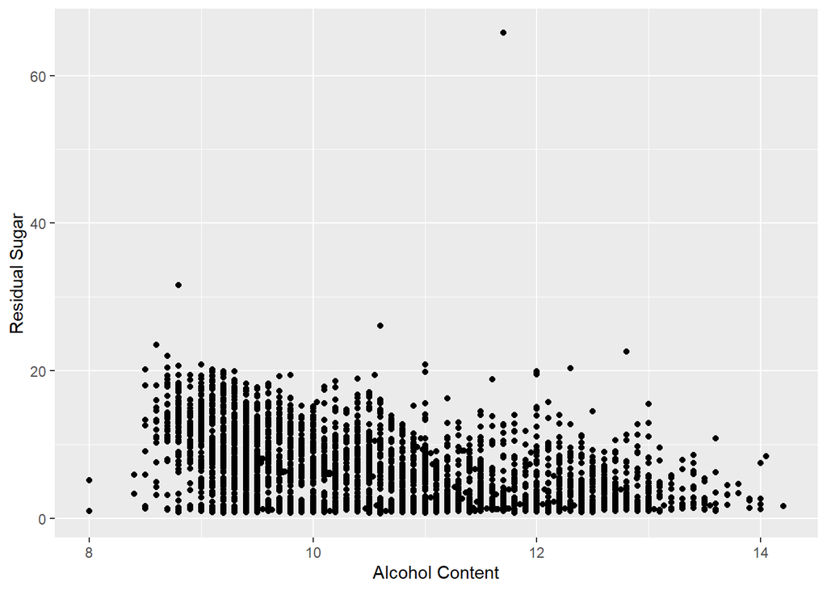

I have summarized both the free and total sulfur dioxides in order to see the proportional comparison. This is followed by a visualization of the comparison which shows the free sulfur dioxide variable area of the graph fits almost perfectly inside of the total sulfur dioxide area.

```
##    Min. 1st Qu.  Median    Mean 3rd Qu.    Max.
##    2.00   23.00   34.00   35.31   46.00  289.00
```

```
##    Min. 1st Qu.  Median    Mean 3rd Qu.    Max.
##     9.0   108.0   134.0   138.4   167.0   440.0
```

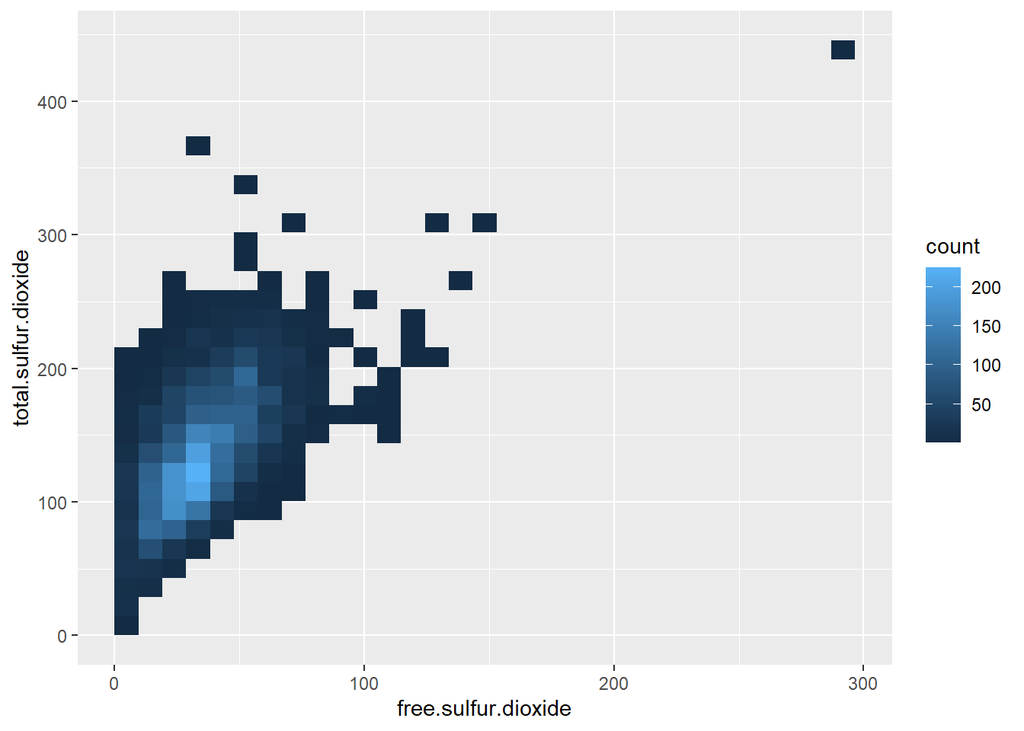

As I mentioned in this sections introductions I have also shown below the comparison between the fixed and volatile acidity rates.

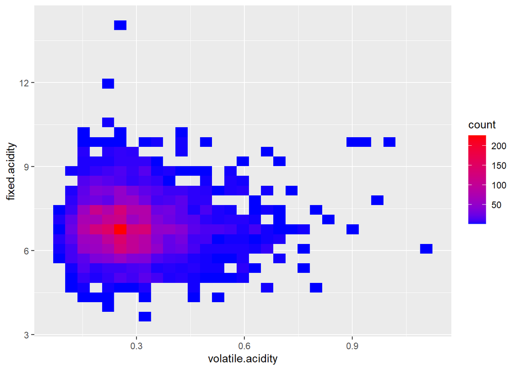

Below is a scatter plot of the comparisons of chlorides to pH measurments.

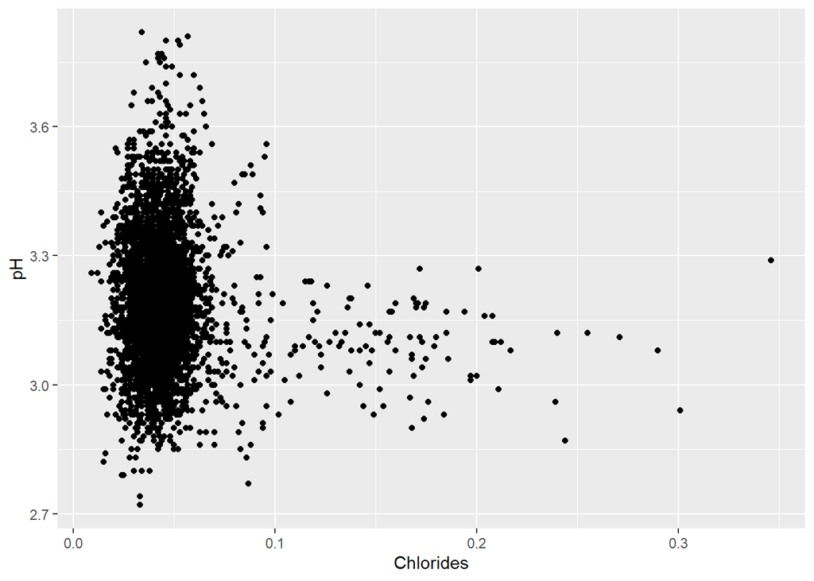

To focus on the main points of the data I have created a scatter plot of Quality and Alcohol content. There are a few lines of data in this graph which would be expected since the scores are for numbers 1-10.

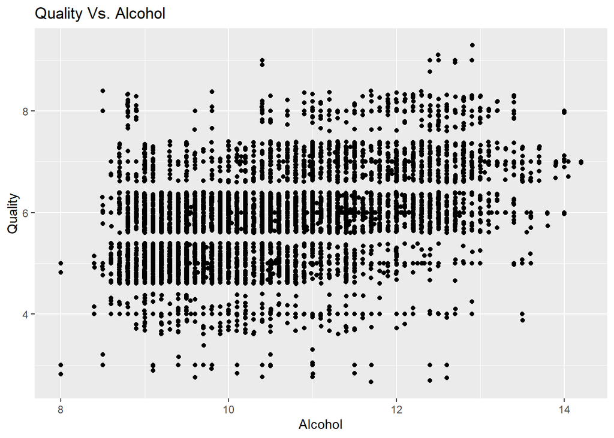

Below again I have used the quality variable and compared it with the residual sugar variable. And again there are measurements near the rated scores.

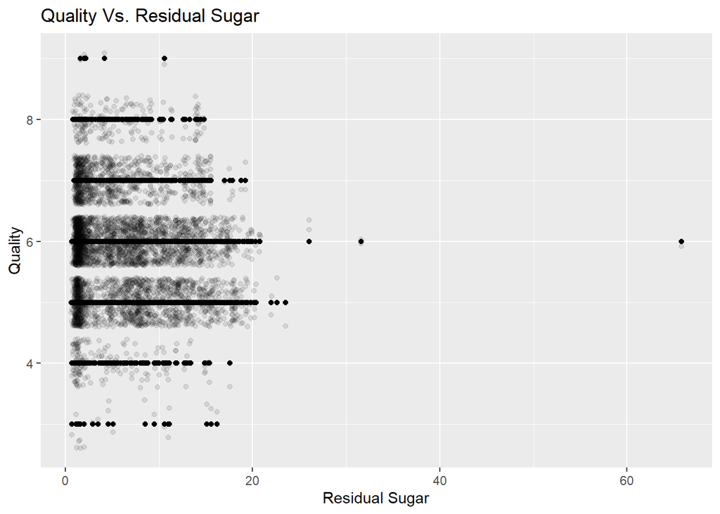

From the graphs above I was not seeing many great comparisons therefore I decided to create a scatterplot matrices that would should the correlations between variables and I can then visualize the variables based on the highest correlations. When creating the matrices it is still a bit hard to see the comparisons so below I have also printed the correlations between variables in number format.

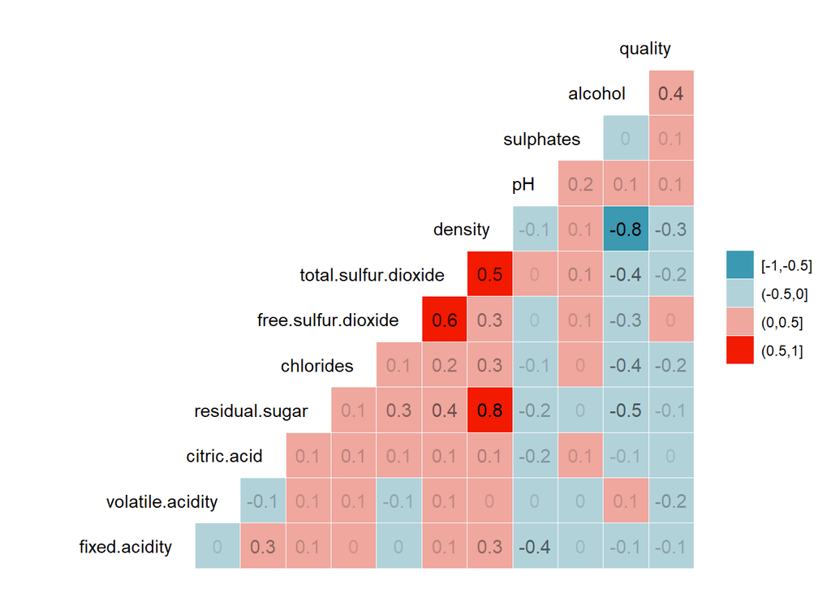

```
##                      fixed.acidity volatile.acidity citric.acid residual.sugar
## fixed.acidity           1.00000000      -0.02269729  0.28918070     0.08902070
## volatile.acidity       -0.02269729       1.00000000 -0.14947181     0.06428606
## citric.acid             0.28918070      -0.14947181  1.00000000     0.09421162
## residual.sugar          0.08902070       0.06428606  0.09421162     1.00000000
## chlorides               0.02308564       0.07051157  0.11436445     0.08868454
## free.sulfur.dioxide    -0.04939586      -0.09701194  0.09407722     0.29909835
## total.sulfur.dioxide    0.09106976       0.08926050  0.12113080     0.40143931
## density                 0.26533101       0.02711385  0.14950257     0.83896645
## pH                     -0.42585829      -0.03191537 -0.16374821    -0.19413345
## sulphates              -0.01714299      -0.03572815  0.06233094    -0.02666437
## alcohol                -0.12088112       0.06771794 -0.07572873    -0.45063122
##                        chlorides free.sulfur.dioxide total.sulfur.dioxide
## fixed.acidity         0.02308564       -0.0493958591          0.091069756
## volatile.acidity      0.07051157       -0.0970119393          0.089260504
## citric.acid           0.11436445        0.0940772210          0.121130798
## residual.sugar        0.08868454        0.2990983537          0.401439311
## chlorides             1.00000000        0.1013923521          0.198910300
## free.sulfur.dioxide   0.10139235        1.0000000000          0.615500965
## total.sulfur.dioxide  0.19891030        0.6155009650          1.000000000
## density               0.25721132        0.2942104109          0.529881324
## pH                   -0.09043946       -0.0006177961          0.002320972
## sulphates             0.01676288        0.0592172458          0.134562367
## alcohol              -0.36018871       -0.2501039415         -0.448892102
##                          density            pH   sulphates     alcohol
## fixed.acidity         0.26533101 -0.4258582910 -0.01714299 -0.12088112
## volatile.acidity      0.02711385 -0.0319153683 -0.03572815  0.06771794
## citric.acid           0.14950257 -0.1637482114  0.06233094 -0.07572873
## residual.sugar        0.83896645 -0.1941334540 -0.02666437 -0.45063122
## chlorides             0.25721132 -0.0904394560  0.01676288 -0.36018871
## free.sulfur.dioxide   0.29421041 -0.0006177961  0.05921725 -0.25010394
## total.sulfur.dioxide  0.52988132  0.0023209718  0.13456237 -0.44889210
## density               1.00000000 -0.0935914935  0.07449315 -0.78013762
## pH                   -0.09359149  1.0000000000  0.15595150  0.12143210
## sulphates             0.07449315  0.1559514973  1.00000000 -0.01743277
## alcohol              -0.78013762  0.1214320987 -0.01743277  1.00000000
```

From viewing the correlations it seems there is a strong negative correlation between density and alcohol. I have pictured this below.

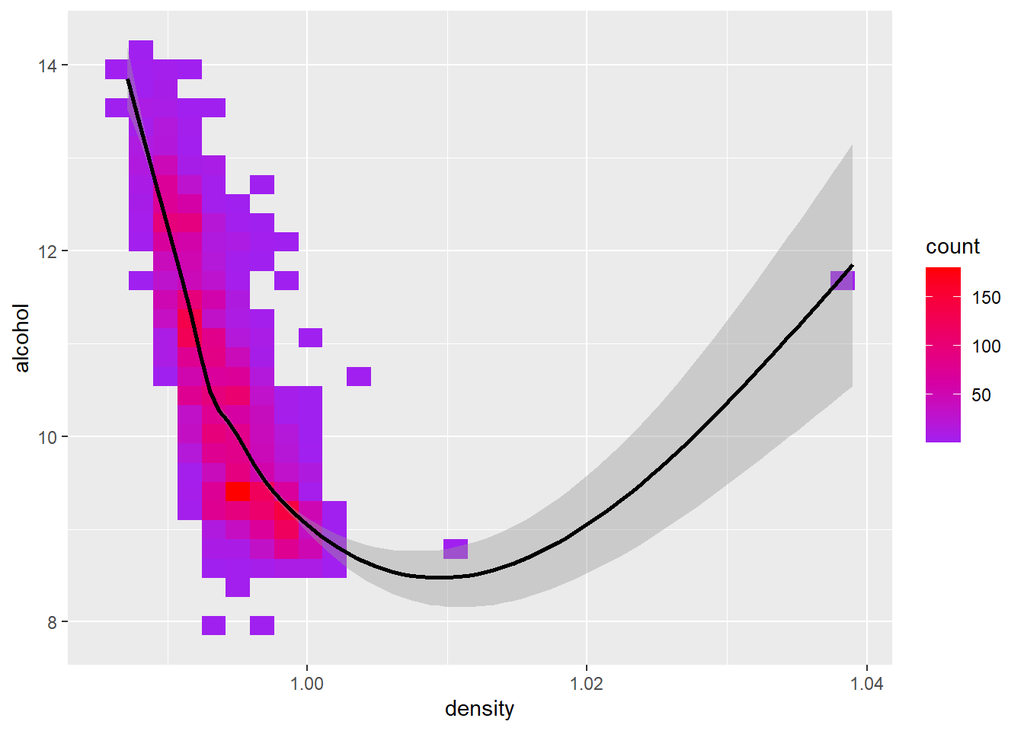

Density on the other hand has a strong positive correlation with residual sugar as pictured below.

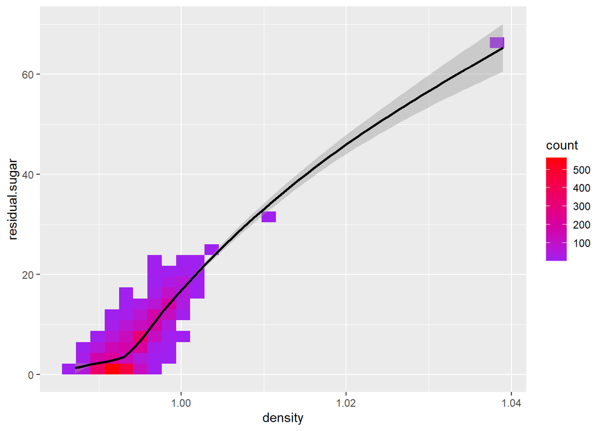

Chloride has a weak negative correlation with alcohol around -.36. This comparison is shown below.

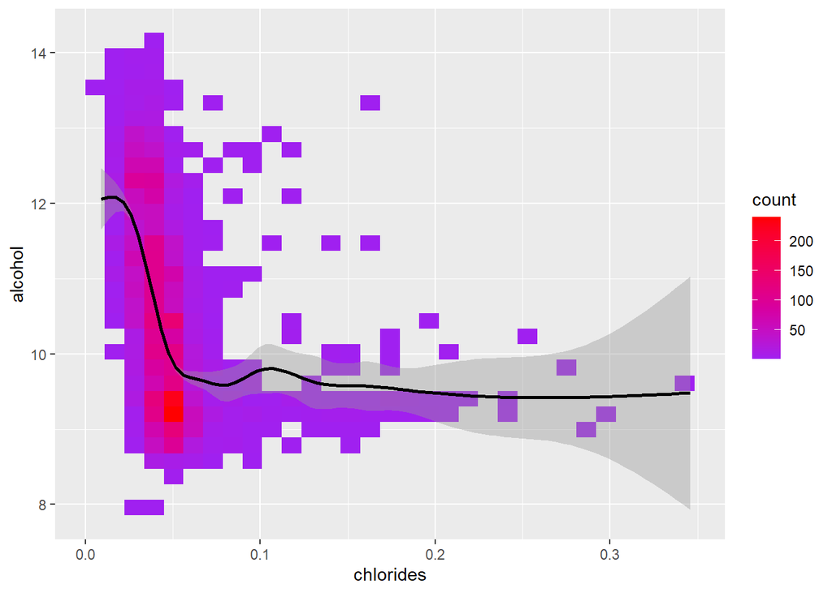

pH and fixed acidity have a weak negative correlation at .43 this is pictured below.

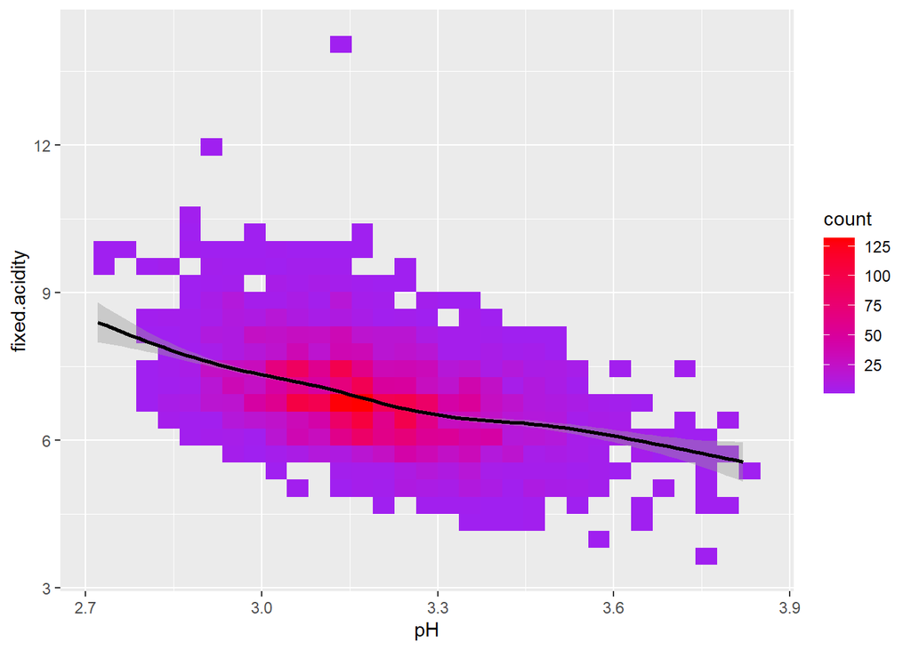

# Bivariate Analysis

Started off by taking a look at the relationship between chemical components that I wanted to see such as alcohol and residual sugar. Then I took a look at the main feature of quality and alcohol content to see the relationship between the two. I then took a look at quality and residual sugar again. I then decided to take a look at each variables correlation between one another. This lead me to present visualizations of the top positively and negatively correlated variables.

investigation. How did the feature(s) of interest vary with other features in  
the dataset? Quality is negatively correlated with density where as quality was positively correlated with alcohol content. Although Alcohol has a weak positive correlation, the positive correlation would be expected when compared to quality.

# Multivariate Plots Section

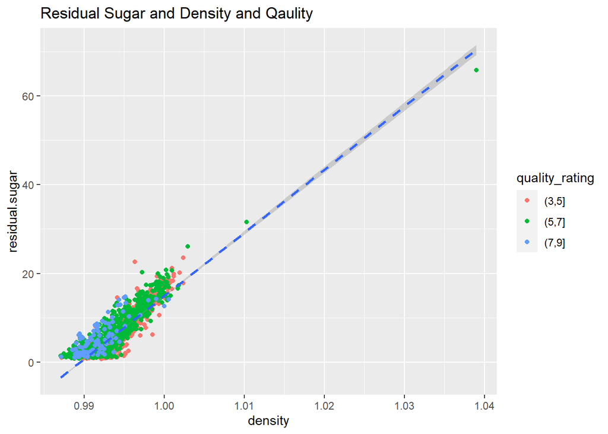

Since alcohol percentage and density had a strong correlation in the previous section I would like to see how this is compared with quality.

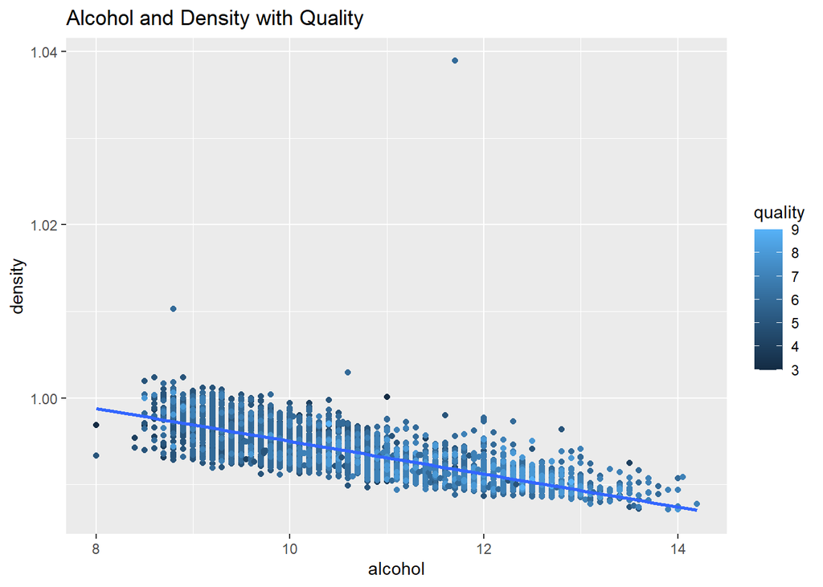

Now I would like to compare the fixed acidity and PH to the quality rating as pictured below.

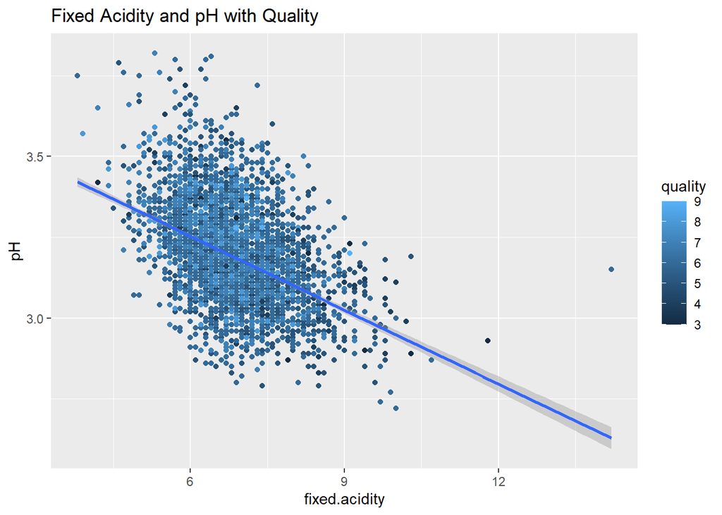

# Multivariate Analysis

### Talk about some of the relationships you observed in this part of the

No

# Final Plots and Summary

It is important to highlight the main points of the data exploration. Below I have added three visualizations that will sum up my findings.

### Plot One

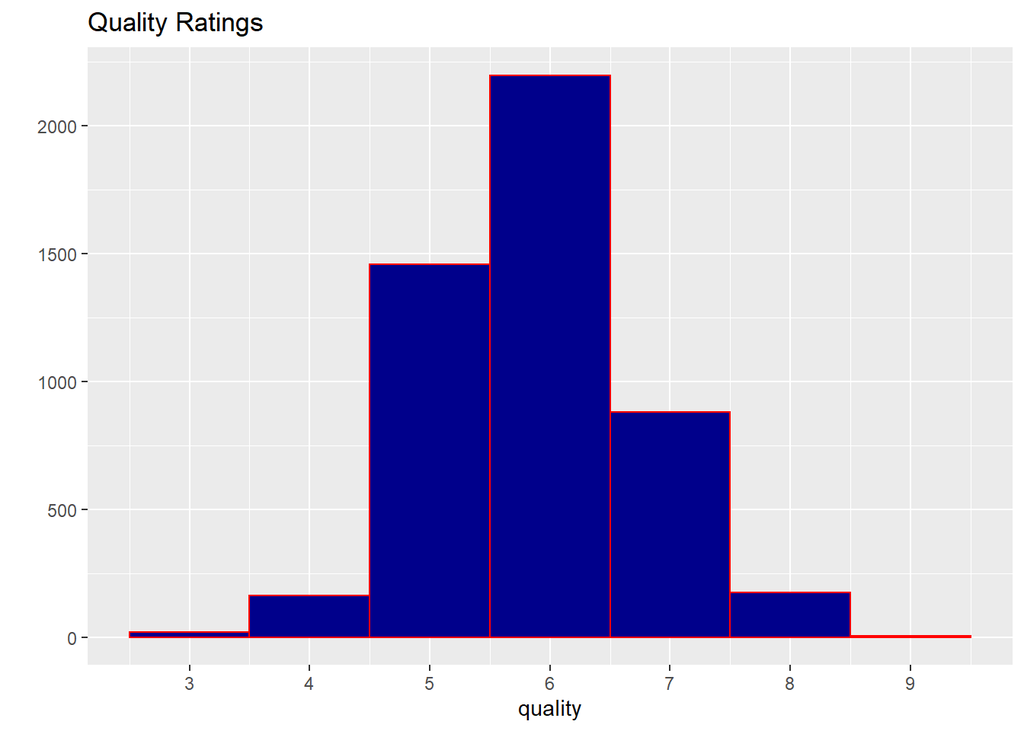

### Description One

The Quality Histogram summary visualization was chosen because the data is mainly pointing to the quality and what chemical components are more often contributing to a higher quality score. This would is the first plot that was performed and an overall visualization of the main points of the graph. What is interesting here is that there are a lot of average scored wines. This makes sense because usually with most drinks or foods there are always a few top competitors and more average rated.

### Plot Two

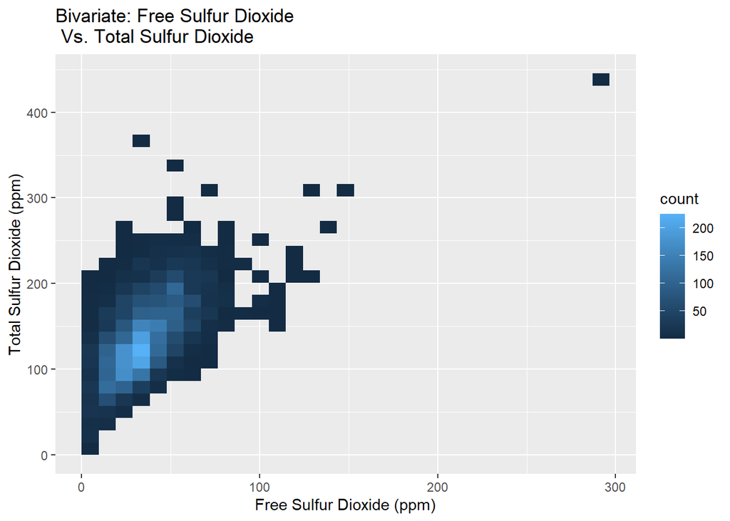

### Description Two

It is interesting to be able to visualize the proportions shown in the summaries. I have chosen this plot from my finds because it is correctly shows the proportional comparison that I found while exxploring.

### Plot Three

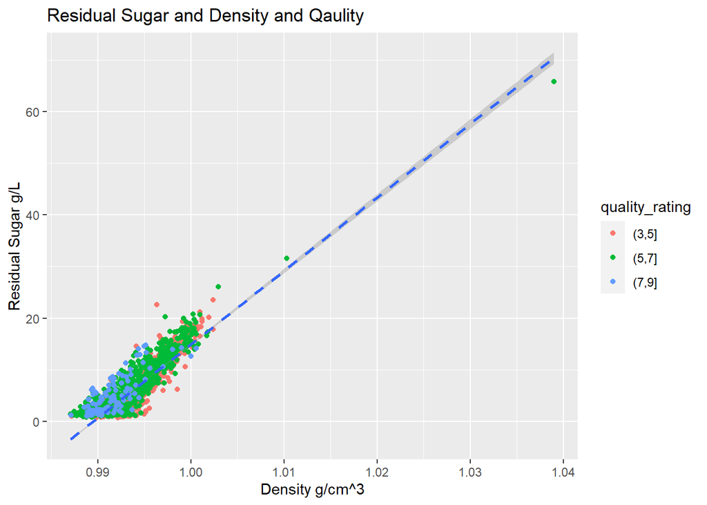

## In the above graph the higher quality rating are scored when there is less sugar and less density. I have chosen this graph because I find it interesting in personal experience that the higher score is with less sugar this makes me think that some of the other chemical components could add value to the sweetness of the wine.

# Reflection

This exploration in creating the graphs and plots were really interesting. I like how r has the helpful tips and guides when coding. This allow me to make a change while coding rather than running the code and searching for a mistake after an error. The scatterplot matrices was the biggest struggle because I could not get it to the correct size to be able to accurately identify each piece of the matrices. However I was able to use the correlation table as a guide. What was surprising and interesting was that I had to research some of the variables from the dataset as well as concepts of creating wines. This allowed me to go beyond the project itself and build on the dataset with other knowledge during the explanations of the findings. For this dataset again I would add the names. It would be interesting to compare the results of the exploration with actual wines, like a taste test. I also red that wine is mostly made up of water, this could be helpful to add. This would most likely not be a contributing factor to the quality but it could add value to other variables such as density.

References: http://www.sthda.com/english/wiki/correlation-matrix-an-r-function-to-do-all-you-need https://github.com/ricardo-yos/data-analyst-nd/blob/master/P4-explore-and-summarize-data/wineQualityReds_EDA.Rmd https://www.dalvinowineco.com/2018/11/24/residual-sugar-in-wine/#:~:text=Residual%20sugar%2C%20or%20RS%2C%20is,in%20the%20wine%20after%20fermentation.&text=After%20this%20chemical%20reaction%2C%20the,weight%20to%20volume%20(%25%20RS.) http://www.piwine.com/media/home-wine-making-basics/using_sulfur_dioxide.pdf https://www.kaggle.com/piyushgoyal443/red-wine-analysis/report https://www.ncbi.nlm.nih.gov/pmc/articles/PMC4973766/ http://www.cookbook-r.com/Graphs/Titles_(ggplot2)/ https://briatte.github.io/ggcorr/